# Stat 361 — Recitation 5

Serenay Çakar

2026-26-03

# Background Theory

## Transformation Methods

Many probability distributions can be generated by applying a deterministic function to one or more random variables from a **known** (easy-to-sample) distribution. This avoids direct numerical inversion of complex CDFs.

### Key Transformation Reference Table

| Input Distribution(s) | Transformation | Result |
| --- | --- | --- |
| $Z \sim N(0,1)$ | $Z^2$ | $\chi^2_1$ |
| $Z_1,\ldots,Z_n \overset{iid}{\sim} N(0,1)$ | $\sum_{i=1}^{n} Z_i^2$ | $\chi^2_n$ |
| $U \sim \chi^2_m,\; V \sim \chi^2_n$ indep. | $F = \dfrac{U/m}{V/n}$ | $F(m,n)$ |
| $Z \sim N(0,1),\; V \sim \chi^2_n$ indep. | $T = \dfrac{Z}{\sqrt{V/n}}$ | $t_n$ |
| $U_i \overset{iid}{\sim} \text{Exp}(\theta)$ | $\sum_{i=1}^{t} U_i$ | $\text{Gamma}(t,\theta)$ |
| $X, Y \sim \text{Exp}(1)$ indep. | $Z = \mu - s\log(X/Y)$ | $\text{Logistic}(\mu,s)$ |
| $X \sim F(n,m)$ | $Z = \dfrac{\log(X)}{2}$ | $\text{Fisher's Z}(n,m)$ |
| $X \sim \text{Weibull}(\lambda, \tfrac{1}{2})$ | $Y = \sqrt{X}$ | $\text{Exponential}(1/\sqrt{\lambda})$ |
| $U \sim \text{Exp}(\lambda)$ | $V = \sum_{i=1}^{t} U_i$ | $\text{Erlang}(t,\lambda)$ |
| $U \sim \text{Exp}(\lambda),\; V = \sum U_i$ | $Z = U/V + 1$ | $\text{Pareto}(1,t)$ |
| $U, V \sim \text{Unif}(0,1)$ indep. (Box–Muller) | $Z_1 = \sqrt{-2\log U}\cos(2\pi V),\quad Z_2 = \sqrt{-2\log U}\sin(2\pi V)$ | $Z_1, Z_2 \overset{iid}{\sim} N(0,1)$ |
| $U \sim \Gamma(r,\lambda),\; V \sim \Gamma(s,\lambda)$ indep. | $X = \dfrac{U}{U+V}$ | $\text{Beta}(r,s)$ |
| $U, V \sim \text{Unif}(0,1)$ indep. | $X = \left\lfloor 1 + \dfrac{\log(V)}{\log(1-(1-\theta)^U)} \right\rfloor$ | $\text{Logarithmic}(\theta)$ |
| $Y \sim N(\mu,\sigma^2)$ | $X = e^Y$ | $\text{Lognormal}(\mu,\sigma^2)$ |

## Convolution vs. Mixture

**Convolution (Sum):** $S = X_1 + X_2 + \cdots + X_n$

- Result is unimodal with increased variance: $E(S) = nE(X)$, $\text{Var}(S) = n\,\text{Var}(X)$
- Simulate by generating $X_1, \ldots, X_n$ independently and summing

**Mixture:** Each observation drawn from distribution $F_j$ with probability $p_j$

- $F_X = p_1 F_{X_1} + p_2 F_{X_2} + \cdots$
- Often **bimodal** — preserves distinct component shapes
- Simulate by drawing $U \sim \text{Unif}(0,1)$, then choosing which component to sample from

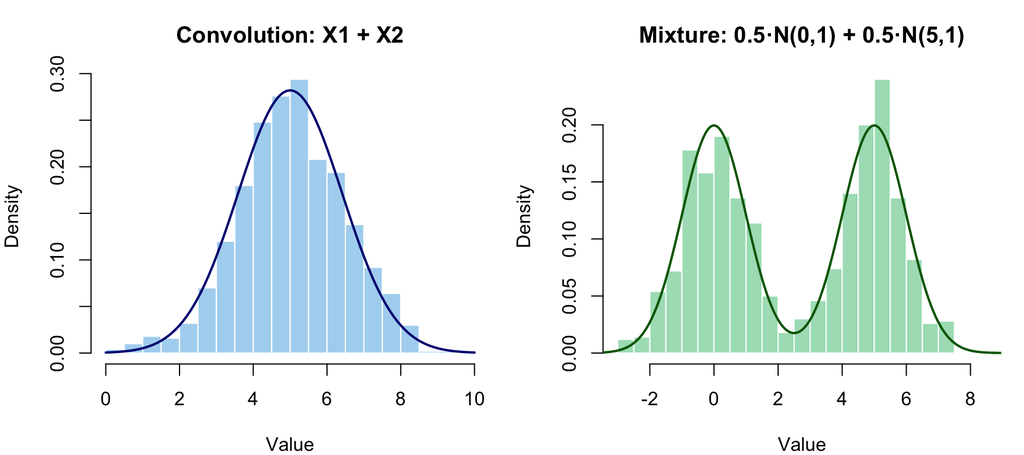

```r
set.seed(361)
n <- 1000

x1 <- rnorm(n, mean = 0, sd = 1)   # N(0,1)
x2 <- rnorm(n, mean = 5, sd = 1)   # N(5,1)

# Convolution: sum the two variables
s <- x1 + x2   # should be N(5, 2)

# Mixture: pick from x1 or x2 with prob 0.5 each
u <- runif(n)
k <- as.integer(u > 0.5)
x <- k * x1 + (1 - k) * x2

par(mfcol = c(1, 2), mar = c(4, 4, 3, 1))

hist(s, prob = TRUE, main = "Convolution: X1 + X2",
     xlab = "Value", col = "#AED6F1", border = "white", breaks = 30)
curve(dnorm(x, 5, sqrt(2)), col = "navy", lwd = 2, add = TRUE)

hist(x, prob = TRUE, main = "Mixture: 0.5·N(0,1) + 0.5·N(5,1)",
     xlab = "Value", col = "#A9DFBF", border = "white", breaks = 30)
xs <- seq(-4, 9, 0.01)
lines(xs, 0.5*dnorm(xs,0,1) + 0.5*dnorm(xs,5,1), col = "darkgreen", lwd = 2)
```

```r
par(mfcol = c(1,1))
```

**Key difference:** The convolution produces a single bell curve centred at the sum of means. The mixture retains the two separate modes — classic **bimodal** shape.

# Question 1 — Gamma(4, 9) via Exponential Convolution

Write a function to generate $n = 10{,}000$ random variables from $\text{Gamma}(4, 9)$ using its relationship with the Exponential distribution. Visualize with a histogram and theoretical density. Compare sample mean and variance with theoretical values.

## Theory

**Key relationship:** Since $t = 4$ is a positive integer:
$$\sum_{i=1}^{4} \text{Exp}(\lambda) \sim
\text{Gamma}(4,\,\lambda)$$

**Inverse transform for Exponential:**
$$X_i = -\frac{1}{\lambda}\log(U_i), \quad U_i \sim
\text{Unif}(0,1)$$

So generating one $\text{Gamma}(4, 9)$ variate requires summing 4 independent $\text{Exp}(9)$ variates:
$$Y = X_1 + X_2 + X_3 + X_4$$

**Theoretical moments:** $E(X) = t/\lambda = 4/9 \approx 0.444$, $\text{Var}(X) = t/\lambda^2 = 4/81 \approx 0.049$

## Solution

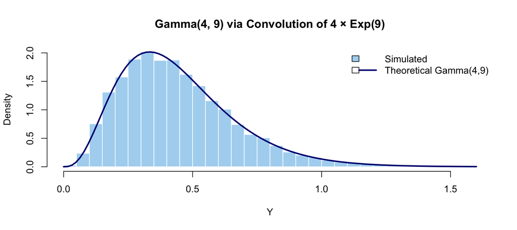

```r
set.seed(361)

# ---------------------------------------------------------------
# gamma_simulation: generates n samples from Gamma(t, lambda)
#   using the convolution of t independent Exp(lambda) r.v.s
#   Each Exp(lambda) variate is produced by the inverse transform:
#   X = -log(U) / lambda,  U ~ Unif(0,1)
# ---------------------------------------------------------------
gamma_simulation <- function(n, t, lambda) {
  # Step 1: Generate a t x n matrix of Uniform(0,1) samples
  U <- matrix(runif(n * t), nrow = t, ncol = n)
  # Step 2: Apply ITM to transform each uniform to Exp(lambda)
  X <- -log(U) / lambda
  # Step 3: Sum down each column → one Gamma(t, lambda) per column
  Y <- colSums(X)
  return(Y)
}

# Parameters
n      <- 1e4
t      <- 4
lambda <- 9

Y <- gamma_simulation(n, t, lambda)

# Plot
hist(Y, probability = TRUE,
     main  = "Gamma(4, 9) via Convolution of 4 × Exp(9)",
     xlab  = "Y", ylab = "Density",
     col   = "#AED6F1", border = "white", breaks = 40)
curve(dgamma(x, shape = t, rate = lambda),
      col = "navy", lwd = 2.5, add = TRUE)
legend("topright", legend = c("Simulated", "Theoretical Gamma(4,9)"),
       fill = c("#AED6F1", NA), lty = c(NA,1),
       lwd = c(NA,2.5), col = c("black","navy"), bty = "n")
```

```r
# Moment comparison
results_q1 <- data.frame(
  Mean     = round(c(t/lambda,       mean(Y)), 5),
  Variance = round(c(t/lambda^2,     var(Y)),  5),
  row.names = c("Theoretical", "Estimated")
)
kable(results_q1, caption = "Gamma(4,9): Theoretical vs Simulated Moments")
```

Gamma(4,9): Theoretical vs Simulated Moments

|  | Mean | Variance |
| --- | --- | --- |
| Theoretical | 0.44444 | 0.04938 |
| Estimated | 0.44201 | 0.04864 |

**Interpretation:** The histogram fits the theoretical $\text{Gamma}(4,9)$ density curve closely. Both the sample mean ($\approx 0.442$) and variance ($\approx 0.049$) match the theoretical values ($0.444$ and $0.049$) — confirming the simulation is correct. By the SLLN, $\bar{Y} \xrightarrow{a.s.} E(Y)$ as $n \to \infty$.

# Question 2 — Chi-Square(5) via Squared Normals

Write a function to generate $n = 10{,}000$ samples from $\chi^2_5$ using its relationship with the standard normal distribution. Visualize and compare estimated moments with theoretical values.

## Theory

**Key relationship:**
$$Z_i
\overset{iid}{\sim} N(0,1) \;\Rightarrow\; \sum_{i=1}^{v} Z_i^2 \sim
\chi^2_v$$

Each $Z_i^2 \sim \chi^2_1$ (a Gamma(1/2, 1/2) distribution). By the **reproductive property** of the Gamma distribution, the sum of $v$ independent $\chi^2_1$ variables is $\chi^2_v$.

**Theoretical moments:** $E(X) = v = 5$, $\text{Var}(X) = 2v = 10$

**Algorithm:** 1. Generate $v \times n$ standard normals 2. Square each value 3. Sum across the $v$ rows for each of the $n$ observations

## Solution

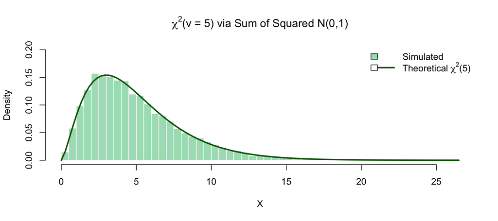

```r
set.seed(361)

# ---------------------------------------------------------------
# chisq_simulation: generates n samples from chi-square(v)
#   by summing v squared N(0,1) random variables
# ---------------------------------------------------------------
chisq_simulation <- function(n, v) {
  # Generate a v x n matrix of standard normals
  Z <- matrix(rnorm(n * v, 0, 1), nrow = v, ncol = n)
  # Sum of squared columns → chi-square(v) per column
  X <- colSums(Z^2)
  return(X)
}

n <- 10000
v <- 5
X <- chisq_simulation(n, v)

# Plot
hist(X, probability = TRUE,
     main  = expression(paste(chi^2, "(v = 5) via Sum of Squared N(0,1)")),
     xlab  = "X", ylab = "Density",
     col   = "#A9DFBF", border = "white", breaks = 40, ylim = c(0, 0.20))
curve(dchisq(x, df = v), col = "darkgreen", lwd = 2.5, add = TRUE)
legend("topright",
       legend = c("Simulated", expression(paste("Theoretical ", chi^2, "(5)"))),
       fill = c("#A9DFBF",NA), lty=c(NA,1), lwd=c(NA,2.5),
       col=c("black","darkgreen"), bty="n")
```

```r
# Moment comparison
results_q2 <- data.frame(
  Mean     = round(c(v,     mean(X)), 5),
  Variance = round(c(2*v,   var(X)),  5),
  row.names = c("Theoretical", "Estimated")
)
kable(results_q2, caption = "Chi-Square(5): Theoretical vs Simulated Moments")
```

Chi-Square(5): Theoretical vs Simulated Moments

|  | Mean | Variance |
| --- | --- | --- |
| Theoretical | 5.00000 | 10.00000 |
| Estimated | 4.99608 | 9.93858 |

**Interpretation:** Each $Z_i^2 \sim \chi^2_1$ contributes $E = 1$, $\text{Var} = 2$. By independence, summing 5 of them gives $E = 5$, $\text{Var} = 10$ — both confirmed by the simulation. Note that $\chi^2_v \equiv \text{Gamma}(v/2,\, 1/2)$, so this is a special case of Question 1.

# Question 3 — Student-t(25) via Normal/Chi-Square Ratio

Write a function to generate $n = 10{,}000$ samples from $t_{25}$ using a transformation method. Visualize with the theoretical density.

## Theory

**Key transformation:**
$$T =
\frac{Z}{\sqrt{V/k}}, \quad Z \sim N(0,1),\; V \sim \chi^2_k \text{
(independent)} \;\Rightarrow\; T \sim t_k$$

**Theoretical moments (for $k > 2$):**
$$E(T) = 0, \qquad
\text{Var}(T) = \frac{k}{k-2} = \frac{25}{23} \approx 1.087$$

The $t$ distribution has heavier tails than $N(0,1)$ — as $k \to \infty$, $t_k \to N(0,1)$.

## Solution

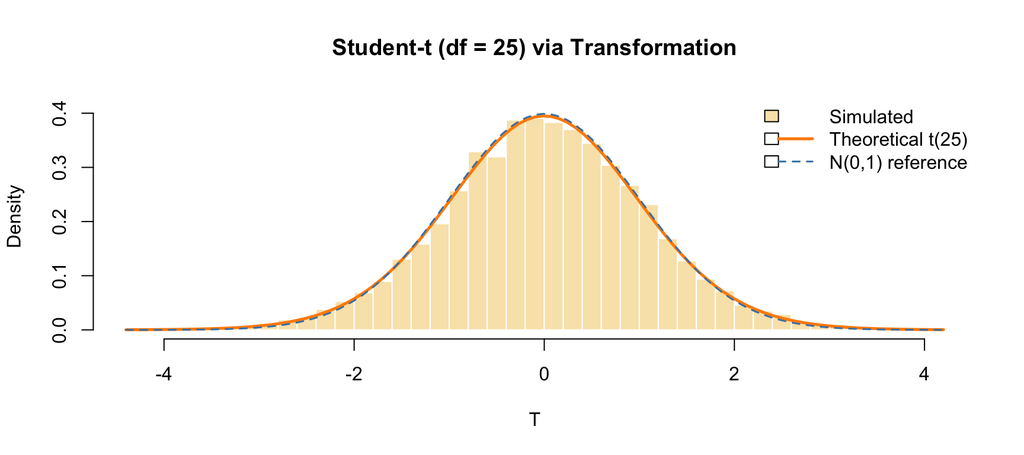

```r
set.seed(361)

# ---------------------------------------------------------------
# tdist_simulation: generates n samples from t(k)
#   using T = Z / sqrt(V/k), where Z ~ N(0,1) and V ~ chi-sq(k)
# ---------------------------------------------------------------
tdist_simulation <- function(n, k) {
  # Numerator: n standard normals
  Z_num <- rnorm(n)
  # Denominator: generate V ~ chi-square(k) as sum of k squared normals
  Z_mat <- matrix(rnorm(n * k), nrow = n, ncol = k)
  V     <- rowSums(Z_mat^2)
  # T-distributed values
  T_vals <- Z_num / sqrt(V / k)
  return(T_vals)
}

n <- 10000
k <- 25
T_values <- tdist_simulation(n, k)

# Plot
hist(T_values, probability = TRUE,
     main = "Student-t (df = 25) via Transformation",
     xlab = "T", ylab = "Density",
     col = "#F9E4B7", border = "white", breaks = 50, ylim = c(0, 0.42))
curve(dt(x, df = k),   col = "darkorange", lwd = 2.5, add = TRUE)
curve(dnorm(x),        col = "steelblue",  lwd = 1.5, lty = 2, add = TRUE)
legend("topright",
       legend = c("Simulated", "Theoretical t(25)", "N(0,1) reference"),
       fill   = c("#F9E4B7", NA, NA),
       lty    = c(NA, 1, 2), lwd = c(NA, 2.5, 1.5),
       col    = c("black","darkorange","steelblue"), bty = "n")
```

```r
# Moment comparison
results_q3 <- data.frame(
  Mean     = round(c(0,         mean(T_values)), 4),
  Variance = round(c(k/(k-2),   var(T_values)),  4),
  row.names = c("Theoretical", "Estimated")
)
kable(results_q3, caption = "t(25): Theoretical vs Simulated Moments")
```

t(25): Theoretical vs Simulated Moments

|  | Mean | Variance |
| --- | --- | --- |
| Theoretical | 0.000 | 1.0870 |
| Estimated | 0.011 | 1.1191 |

**Interpretation:** The $t_{25}$ distribution is symmetric around 0 (confirmed by sample mean $\approx 0$) but slightly heavier-tailed than $N(0,1)$ — visible in the comparison with the dashed blue curve. The variance ($\approx 1.087$) exceeds 1, reflecting those heavier tails.

# Question 4 — Pareto(1, 18) via Erlang Transformation

Generate $n = 10^5$ samples from $\text{Pareto}(1, 18)$ using the relationship between Exponential(8), Erlang, and Pareto distributions. Use only `runif()` to generate random numbers. Verify the sample has Pareto(1, 18) properties.

## Theory

**Chain of transformations:**

**Step 1** — Exponential via ITM:
$$X_i = -\frac{1}{\lambda}\log U_i, \quad U_i \sim
\text{Unif}(0,1) \;\Rightarrow\; X_i \sim
\text{Exp}(\lambda)$$

**Step 2** — Erlang via convolution:
$$V = \sum_{i=1}^{t} X_i \sim \text{Erlang}(t,
\lambda)$$

**Step 3** — Pareto via ratio:
$$Z = \frac{U}{V} + 1 \sim \text{Pareto}(1,
t)$$

**Pareto PDF:** $f(x) = \alpha\beta^\alpha / x^{\alpha+1}$, for $x > \beta$

**Moments:** $E(X) = t/(t-1) = 18/17 \approx 1.059$ (for $t > 1$), $\text{Var}(X) = t/[(t-1)^2(t-2)] = 18/(17^2 \times 16) \approx 0.00389$

## Solution

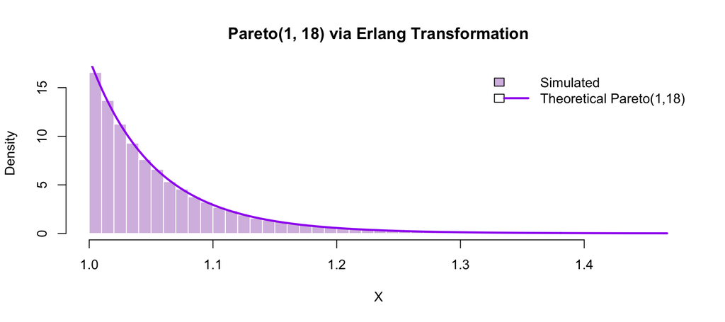

```r
# install.packages("sads")
library(sads)   # provides dpareto()

set.seed(361)

n      <- 1e5
t      <- 18
lambda <- 8

# ---------------------------------------------------------------
# Step 1: Generate a t x n matrix of Uniform(0,1) values
#         Each column produces t Exp(lambda) variates via ITM
# ---------------------------------------------------------------
U <- matrix(runif(n * t), nrow = t, ncol = n)

# Step 2: Apply ITM → each entry becomes Exp(lambda)
exponential <- -log(U) / lambda

# Step 3: Column sums → Erlang(t, lambda) per sample
#         erlang[j] = sum of t Exp(lambda) values = V
erlang <- colSums(exponential)

# Step 4: Use the first row as the U ~ Exp(lambda) numerator
#         Z = U/V + 1 ~ Pareto(1, t)
# Note: exponential[1,] is one Exp(lambda) row (independent of erlang
#       only if we use a separate draw — here we use a fresh row)
U_num  <- -log(runif(n)) / lambda   # fresh Exp(lambda) for numerator
pareto <- (U_num / erlang) + 1

# Plot
hist(pareto, prob = TRUE, breaks = 100,
     xlim = c(min(pareto), quantile(pareto, 0.999)),
     main = "Pareto(1, 18) via Erlang Transformation",
     xlab = "X", col = "#D7BDE2", border = "white")
y_seq <- seq(1, quantile(pareto, 0.999), 0.001)
lines(y_seq, dpareto(y_seq, scale = 1, shape = t),
      col = "purple", lwd = 2.5)
legend("topright", legend = c("Simulated", "Theoretical Pareto(1,18)"),
       fill = c("#D7BDE2",NA), lty=c(NA,1), lwd=c(NA,2.5),
       col=c("black","purple"), bty="n")
```

```r
# Moment verification
E_pareto   <- t / (t - 1)
Var_pareto <- t / ((t-1)^2 * (t-2))

results_q4 <- data.frame(
  Mean     = round(c(E_pareto,   mean(pareto)), 5),
  Variance = round(c(Var_pareto, var(pareto)),  5),
  row.names = c("Theoretical", "Estimated")
)
kable(results_q4, caption = "Pareto(1,18): Theoretical vs Simulated Moments")
```

Pareto(1,18): Theoretical vs Simulated Moments

|  | Mean | Variance |
| --- | --- | --- |
| Theoretical | 1.05882 | 0.00389 |
| Estimated | 1.05896 | 0.00393 |

**Interpretation:** The Pareto distribution has a very heavy right tail — most mass is near the lower bound of 1. The histogram fits the theoretical Pareto(1,18) density well. The estimated mean is close to $18/17 \approx 1.059$. Only `runif()` was used at the random-number generation stage, with the Exponential-Erlang-Pareto chain providing the full transformation.

# Question 5 — Logistic(5, 7) via Exponential Ratio

Generate $n = 10^5$ samples from $\text{Logistic}(5, 7)$ using the transformation method based on two independent $\text{Exp}(1)$ random variables. Compare histogram with theoretical density.

## Theory

**Key transformation:**
$$X
\sim \text{Exp}(1),\quad Y \sim \text{Exp}(1) \text{ independent}
\;\Rightarrow\; Z = \mu - s\log\!\left(\frac{X}{Y}\right) \sim
\text{Logistic}(\mu, s)$$

**Inverse transform for Exponential:**
$$X = -\frac{1}{\lambda}\log U, \quad U \sim
\text{Unif}(0,1)$$

**Logistic PDF:**
$$f(x) =
\frac{e^{-(x-\mu)/s}}{s\left(1 + e^{-(x-\mu)/s}\right)^2}$$

**Moments:** $E(Z) = \mu = 5$, $\text{Var}(Z) = s^2\pi^2/3 = 49\pi^2/3 \approx 161.1$

## Solution

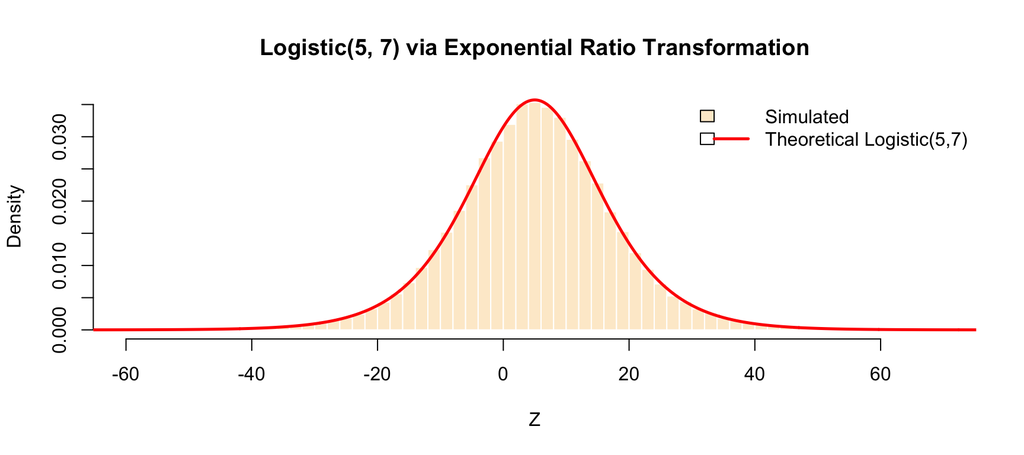

```r
set.seed(361)

n      <- 1e5
lambda <- 1
mu     <- 5
s      <- 7

# ---------------------------------------------------------------
# Generate two independent Exp(1) variates via ITM
# ---------------------------------------------------------------
u1 <- runif(n)
x  <- -log(u1) / lambda   # X ~ Exp(1)

u2 <- runif(n)
y  <- -log(u2) / lambda   # Y ~ Exp(1)

# Apply the Logistic transformation
logistic_sample <- mu - s * log(x / y)

# Plot
hist(logistic_sample, prob = TRUE,
     main = "Logistic(5, 7) via Exponential Ratio Transformation",
     xlab = "Z", col = "#FDEBD0", border = "white",
     breaks = 80, xlim = c(-60, 70))

# Overlay theoretical Logistic PDF
a_seq <- seq(-80, 90, 0.1)
logistic_pdf <- exp(-(a_seq - mu)/s) / (s * (1 + exp(-(a_seq - mu)/s))^2)
lines(a_seq, logistic_pdf, col = "red", lwd = 2.5)

legend("topright", legend = c("Simulated", "Theoretical Logistic(5,7)"),
       fill = c("#FDEBD0",NA), lty=c(NA,1), lwd=c(NA,2.5),
       col=c("black","red"), bty="n")
```

```r
# Moment comparison
results_q5 <- data.frame(
  Mean     = round(c(mu,               mean(logistic_sample)), 4),
  Variance = round(c(s^2 * pi^2 / 3,   var(logistic_sample)),  4),
  row.names = c("Theoretical", "Estimated")
)
kable(results_q5, caption = "Logistic(5,7): Theoretical vs Simulated Moments")
```

Logistic(5,7): Theoretical vs Simulated Moments

|  | Mean | Variance |
| --- | --- | --- |
| Theoretical | 5.0000 | 161.2035 |
| Estimated | 4.9748 | 161.9384 |

**Interpretation:** The Logistic distribution is symmetric around $\mu = 5$ with heavier tails than the Normal. The sample mean closely matches $\mu = 5$. The large variance ($\approx 161$) reflects the wide, heavy-tailed shape — note the x-axis extends well beyond $\pm 30$. The theoretical density (red curve) fits the histogram well across the entire range.

# Question 6 — F(2, 8) via Chi-Square Ratio

Generate $n = 10^5$ samples from $F(2, 8)$ using the appropriate transformation. Compare histogram with the theoretical $F$ density.

## Theory

**Key transformation:**
$$U
\sim \chi^2_m, \quad V \sim \chi^2_n \text{ (independent)}
\;\Rightarrow\; F = \frac{U/m}{V/n} \sim F(m, n)$$

We generate each $\chi^2$ variable as the sum of squared standard normals (from Question 2).

**Theoretical moments (for $n > 4$):**
$$E(F) = \frac{n}{n-2}
= \frac{8}{6} \approx 1.333, \qquad \text{Var}(F) =
\frac{2n^2(m+n-2)}{m(n-2)^2(n-4)} = \frac{2 \cdot 64 \cdot 8}{2 \cdot 36
\cdot 4} = \frac{1024}{288} \approx 3.556$$

## Solution

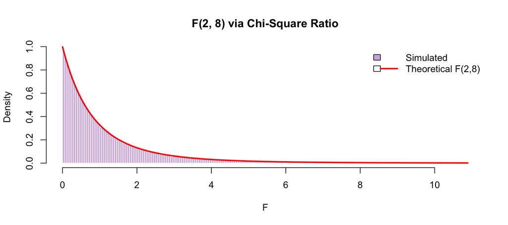

```r
set.seed(361)

N <- 1e5
m <- 2
n <- 8

# ---------------------------------------------------------------
# Generate U ~ chi-square(m) and V ~ chi-square(n) independently
# U = sum of m squared N(0,1) values (one per column)
# V = sum of n squared N(0,1) values (one per column)
# ---------------------------------------------------------------
z1         <- matrix(rnorm(m * N), nrow = m, ncol = N)
z2         <- matrix(rnorm(n * N), nrow = n, ncol = N)
U          <- colSums(z1^2)   # U ~ chi-square(m=2)
V          <- colSums(z2^2)   # V ~ chi-square(n=8)
Rv_F       <- (U / m) / (V / n)   # F(m,n) = F(2,8)

# Plot (truncate right tail for readability)
x_lim <- quantile(Rv_F, 0.995)
hist(Rv_F, breaks = "FD", prob = TRUE,
     main  = "F(2, 8) via Chi-Square Ratio",
     xlab  = "F", col = "#D2B4DE", border = "white",
     xlim  = c(0, x_lim))
a_seq <- seq(0.001, x_lim, 0.01)
lines(a_seq, df(a_seq, df1 = m, df2 = n), col = "red", lwd = 2.5)
legend("topright", legend = c("Simulated", "Theoretical F(2,8)"),
       fill = c("#D2B4DE",NA), lty=c(NA,1), lwd=c(NA,2.5),
       col=c("black","red"), bty="n")
```

```r
# Moment comparison
E_F   <- n / (n - 2)
Var_F <- (2 * n^2 * (m + n - 2)) / (m * (n-2)^2 * (n-4))

results_q6 <- data.frame(
  Mean     = round(c(E_F,   mean(Rv_F)), 4),
  Variance = round(c(Var_F, var(Rv_F)),  4),
  row.names = c("Theoretical", "Estimated")
)
kable(results_q6, caption = "F(2,8): Theoretical vs Simulated Moments")
```

F(2,8): Theoretical vs Simulated Moments

|  | Mean | Variance |
| --- | --- | --- |
| Theoretical | 1.3333 | 3.5556 |
| Estimated | 1.3348 | 3.7636 |

**Interpretation:** The $F(2,8)$ distribution is right-skewed and defined on $(0, \infty)$. The mean exceeds 1 ($\approx 1.333$) and the variance is large ($\approx 3.556$) due to the heavy right tail. The red theoretical density line closely tracks the simulated histogram. Note: the x-axis is truncated at the 99.5th percentile for visual clarity, as a few extreme outliers are expected.

# Question 7 — Beta(3, 5) via Gamma Ratio

Write a function to generate $n = 10{,}000$ samples from $\text{Beta}(3, 5)$ using the Gamma-to-Beta relationship, with $\lambda = 6$. Check the histogram, add theoretical density, and compare moments.

## Theory

**Key transformation:**
$$U
\sim \text{Gamma}(r, \lambda), \quad V \sim \text{Gamma}(s, \lambda)
\text{ (independent)} \;\Rightarrow\; X = \frac{U}{U+V} \sim
\text{Beta}(r, s)$$

We build each Gamma from Exponential variates via ITM:
$$G_1 = \sum_{i=1}^{3} E_i \sim \text{Gamma}(3, 6),
\quad G_2 = \sum_{i=1}^{5} E_i \sim \text{Gamma}(5, 6)$$
where each $E_i = -\frac{1}{6}\log U_i$.

Then: $\text{Beta} = G_1 / (G_1 + G_2) \sim \text{Beta}(3, 5)$

**Theoretical moments:**
$$E(X) = \frac{r}{r+s} = \frac{3}{8} = 0.375,
\qquad \text{Var}(X) = \frac{rs}{(r+s)^2(r+s+1)} = \frac{15}{64 \times
9} \approx 0.026$$

## Solution

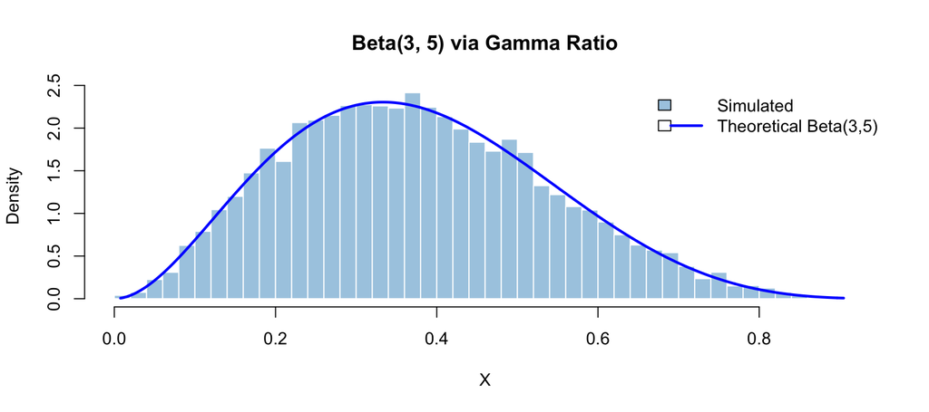

```r
set.seed(361)

# ---------------------------------------------------------------
# beta_sim: generates n samples from Beta(r, s) using the
#   Gamma(r,lambda) / [Gamma(r,lambda) + Gamma(s,lambda)] relation
#   Each Gamma is built from r (or s) Exp(lambda) variates via ITM
# ---------------------------------------------------------------
beta_sim <- function(n, r, s, lambda) {
  # First Gamma: G1 ~ Gamma(r, lambda)
  u1 <- matrix(runif(n * r), nrow = r, ncol = n)
  e1 <- -log(u1) / lambda
  G1 <- colSums(e1)

  # Second Gamma: G2 ~ Gamma(s, lambda)
  u2 <- matrix(runif(n * s), nrow = s, ncol = n)
  e2 <- -log(u2) / lambda
  G2 <- colSums(e2)

  # Beta ratio
  beta_sample <- G1 / (G1 + G2)
  return(beta_sample)
}

n      <- 10000
r      <- 3
s      <- 5
lambda <- 6

beta_sample <- beta_sim(n, r, s, lambda)

# Plot
hist(beta_sample, prob = TRUE,
     main = "Beta(3, 5) via Gamma Ratio",
     xlab = "X", col = "#A9CCE3", border = "white", breaks = 40)
a_seq <- seq(min(beta_sample), max(beta_sample), 0.001)
lines(a_seq, dbeta(a_seq, r, s), col = "blue", lwd = 2.5)
legend("topright", legend = c("Simulated", "Theoretical Beta(3,5)"),
       fill = c("#A9CCE3",NA), lty=c(NA,1), lwd=c(NA,2.5),
       col=c("black","blue"), bty="n")
```

```r
# Moment comparison
results_q7 <- data.frame(
  Mean     = round(c(r/(r+s),               mean(beta_sample)), 5),
  Variance = round(c(r*s/((r+s)^2*(r+s+1)), var(beta_sample)),  5),
  row.names = c("Theoretical", "Estimated")
)
kable(results_q7, caption = "Beta(3,5): Theoretical vs Simulated Moments")
```

Beta(3,5): Theoretical vs Simulated Moments

|  | Mean | Variance |
| --- | --- | --- |
| Theoretical | 0.37500 | 0.02604 |
| Estimated | 0.37494 | 0.02632 |

**Interpretation:** The theoretical density line fits the simulated histogram precisely. The sample mean ($\approx 0.375$) and variance ($\approx 0.026$) match the theoretical values closely. This confirms that the Gamma-ratio transformation correctly produces Beta-distributed samples. Note that $\lambda = 6$ cancels out in the ratio $G_1/(G_1+G_2)$, so the Beta distribution is invariant to $\lambda$.

# Question 8 — Lognormal(1, 1) via Normal Transformation

Write a function to generate $n = 1000$ samples from $\text{Lognormal}(\mu=1, \sigma=1)$ using the transformation $X = e^Y$ where $Y \sim N(\mu, \sigma^2)$. Compare histogram with theoretical density and validate with a QQ plot.

## Theory

**Key transformation:**
$$Y
\sim N(\mu, \sigma^2) \;\Rightarrow\; X = e^Y \sim \text{Lognormal}(\mu,
\sigma^2)$$

This is simply the exponential function applied to a Normal variate — the most direct transformation available.

**Theoretical moments:**
$$E(X) = e^{\mu + \sigma^2/2} = e^{1.5} \approx
4.482, \qquad \text{Var}(X) = (e^{\sigma^2}-1)\,e^{2\mu+\sigma^2} =
(e-1)\,e^3 \approx 34.51$$

The Lognormal is right-skewed — mean $>$ median $>$ mode.

## Solution

```r
set.seed(361)

# ---------------------------------------------------------------
# LogNormal: generate n samples from Lognormal(mu, sigma)
#   using X = exp(Y), Y ~ N(mu, sigma)
# ---------------------------------------------------------------
LogNormal <- function(n, mu, sigma) {
  y <- rnorm(n, mu, sigma)   # Step 1: generate Normal variates
  x <- exp(y)                # Step 2: exponentiate → Lognormal
  return(x)
}

mu    <- 1
sigma <- 1
sample_ln <- LogNormal(1000, mu, sigma)

cat("Summary of generated Lognormal sample:\n")
```

```
## Summary of generated Lognormal sample:
```

```r
print(summary(sample_ln))
```

```
##    Min. 1st Qu.  Median    Mean 3rd Qu.    Max.
##  0.1264  1.3527  2.7836  4.7362  5.9722 82.1906
```

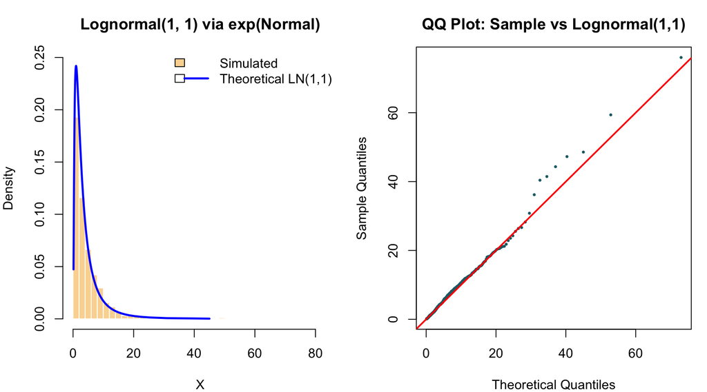

```r
par(mfrow = c(1, 2), mar = c(4, 4, 3, 1))

# Histogram with theoretical density
hist(sample_ln, breaks = "Scott", prob = TRUE,
     main = "Lognormal(1, 1) via exp(Normal)",
     xlab = "X", col = "#FAD7A0", border = "white", ylim = c(0, 0.25))
y_pts <- qlnorm(ppoints(200), mu, sigma)
fy    <- dlnorm(y_pts, mu, sigma)
lines(y_pts, fy, col = "blue", lwd = 2.5)
legend("topright", legend = c("Simulated", "Theoretical LN(1,1)"),
       fill = c("#FAD7A0",NA), lty=c(NA,1), lwd=c(NA,2.5),
       col=c("black","blue"), bty="n")

# QQ plot against theoretical Lognormal quantiles
Q_theo <- qlnorm(ppoints(1000), mu, sigma)
Q_samp <- quantile(sample_ln, ppoints(1000))
qqplot(Q_theo, Q_samp,
       main = "QQ Plot: Sample vs Lognormal(1,1)",
       xlab = "Theoretical Quantiles",
       ylab = "Sample Quantiles",
       col  = "#1F6B75", pch = 16, cex = 0.5)
abline(0, 1, col = "red", lwd = 2)
```

```r
par(mfrow = c(1,1))

# Moment comparison
results_q8 <- data.frame(
  Mean     = round(c(exp(mu + sigma^2/2),           mean(sample_ln)), 4),
  Variance = round(c((exp(sigma^2)-1)*exp(2*mu+sigma^2), var(sample_ln)),  3),
  row.names = c("Theoretical", "Estimated")
)
kable(results_q8, caption = "Lognormal(1,1): Theoretical vs Simulated Moments")
```

Lognormal(1,1): Theoretical vs Simulated Moments

|  | Mean | Variance |
| --- | --- | --- |
| Theoretical | 4.4817 | 34.513 |
| Estimated | 4.7362 | 40.044 |

# Question 9 — Gamma Convolution vs. Mixture

Let $X_1 \sim \text{Gamma}(3,3)$ and $X_2 \sim \text{Gamma}(3,5)$ be independent. Compare histograms of the **convolution** $S = X_1 + X_2$ and the **mixture** $F_X = 0.4 F_{X_1} + 0.6 F_{X_2}$ using $n = 1000$ samples.

## Theory

**Convolution of Gamma distributions:**

When $X_1 \sim \text{Gamma}(\alpha_1, \beta)$ and $X_2 \sim \text{Gamma}(\alpha_2, \beta)$ are independent with the **same rate**:
$$X_1 + X_2 \sim
\text{Gamma}(\alpha_1 + \alpha_2,\, \beta)$$

**However**, $X_1$ and $X_2$ here have **different rates** ($\beta = 3$ and $\beta = 5$), so the sum does **not** follow a standard Gamma. Instead, it follows a hypoexponential-type distribution.

**Expected values:**
$$E(S) =
E(X_1) + E(X_2) = \frac{3}{3} + \frac{3}{5} = 1 + 0.6 = 1.6$$
$$\text{Var}(S) = \text{Var}(X_1) +
\text{Var}(X_2) = \frac{3}{9} + \frac{3}{25} = 0.333 + 0.12 =
0.453$$

**Mixture moments:**
$$E(X) =
0.4 \cdot E(X_1) + 0.6 \cdot E(X_2) = 0.4 \times 1 + 0.6 \times 0.6 =
0.76$$

## Solution

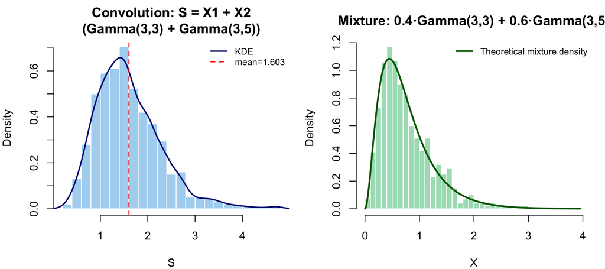

```r
set.seed(361)
n <- 1000

# Generate samples from two Gamma distributions
x1 <- rgamma(n, shape = 3, rate = 3)   # Gamma(3,3): E=1,  Var=0.333
x2 <- rgamma(n, shape = 3, rate = 5)   # Gamma(3,5): E=0.6, Var=0.12

# Convolution: S = X1 + X2
s <- x1 + x2

# Mixture: select X1 with prob 0.4, X2 with prob 0.6
u     <- runif(n)
k_mix <- as.integer(u < 0.4)   # 1 with prob 0.4 → draw from X1
x_mix <- k_mix * x1 + (1 - k_mix) * x2

par(mfcol = c(1, 2), mar = c(4, 4, 3, 1))

hist(s, prob = TRUE, col = "#AED6F1", border = "white",
     main = "Convolution: S = X1 + X2\n(Gamma(3,3) + Gamma(3,5))",
     xlab = "S", breaks = 30)
# No simple closed form — overlay kernel density estimate
lines(density(s), col = "navy", lwd = 2)
abline(v = mean(s), col = "red", lty = 2, lwd = 1.5)
legend("topright", c("KDE", paste0("mean=", round(mean(s),3))),
       lty=c(1,2), lwd=c(2,1.5), col=c("navy","red"), bty="n", cex=0.8)

hist(x_mix, prob = TRUE, col = "#A9DFBF", border = "white",
     main = "Mixture: 0.4·Gamma(3,3) + 0.6·Gamma(3,5)",
     xlab = "X", breaks = 30)
x_seq <- seq(0, max(x_mix), 0.01)
lines(x_seq,
      0.4 * dgamma(x_seq, 3, 3) + 0.6 * dgamma(x_seq, 3, 5),
      col = "darkgreen", lwd = 2.5)
legend("topright", "Theoretical mixture density",
       lty=1, lwd=2.5, col="darkgreen", bty="n", cex=0.8)
```

```r
par(mfcol = c(1,1))

# Summary statistics
results_q9 <- data.frame(
  Theoretical_Mean = c(3/3 + 3/5, 0.4*(3/3) + 0.6*(3/5)),
  Sample_Mean      = round(c(mean(s), mean(x_mix)), 4),
  Theoretical_Var  = c(3/9 + 3/25, NA),
  Sample_Var       = round(c(var(s), var(x_mix)), 4),
  row.names = c("Convolution S", "Mixture X")
)
kable(results_q9, caption = "Q9: Convolution and Mixture Summary Statistics")
```

Q9: Convolution and Mixture Summary Statistics

|  | Theoretical_Mean | Sample_Mean | Theoretical_Var | Sample_Var |
| --- | --- | --- | --- | --- |
| Convolution S | 1.60 | 1.6032 | 0.4533333 | 0.4665 |
| Mixture X | 0.76 | 0.7815 | NA | 0.2609 |

# Question 10 — Normal Location Mixture

Generate $n = 1000$ samples from a normal location mixture with components $N(0,1)$ and $N(3,1)$ and mixing probability $p_1 = 0.75$. Graph the histogram with density superimposed. Repeat for different values of $p_1$ and observe whether the mixture appears bimodal.

## Theory

**Normal location mixture:**
$$F_X(x) = p_1 \Phi\!\left(\frac{x-0}{1}\right) +
(1-p_1)\Phi\!\left(\frac{x-3}{1}\right)$$

**PDF:**
$$f(x) = p_1 \cdot
\phi(x;\,0,1) + (1-p_1) \cdot \phi(x;\,3,1)$$

**Simulation algorithm:** 1. For each observation, draw $\mu_i \in \{0, 3\}$ with probabilities $\{p_1, 1-p_1\}$ 2. Generate $X_i \sim N(\mu_i, 1)$

**Bimodality condition:** The mixture is bimodal when the means are sufficiently separated relative to the standard deviations. With $\mu_1=0$, $\mu_2=3$, $\sigma=1$ (separation = 3σ), bimodality can emerge — its visibility depends on the mixing weights $p_1$.

## Solution — Single Case ($p_1 = 0.75$)

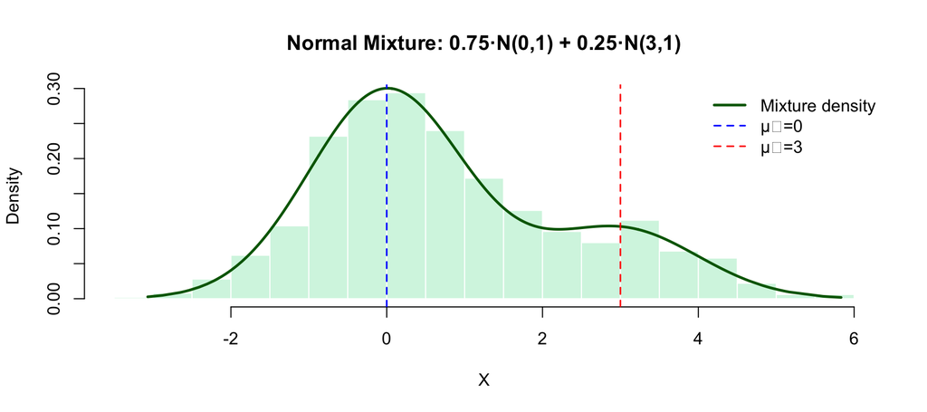

```r
set.seed(361)
n <- 1000
p <- 0.75

# Step 1: Randomly assign each observation to a component
mu_i <- sample(c(0, 3), size = n, replace = TRUE, prob = c(p, 1 - p))

# Step 2: Generate from the assigned component
x <- rnorm(n, mean = mu_i, sd = 1)

# Plot
hist(x, breaks = "Scott", prob = TRUE,
     main  = paste0("Normal Mixture: 0.75·N(0,1) + 0.25·N(3,1)"),
     xlab  = "X", col = "#D5F5E3", border = "white")
y_sorted <- sort(x)
fy       <- p * dnorm(y_sorted, 0, 1) + (1-p) * dnorm(y_sorted, 3, 1)
lines(y_sorted, fy, col = "darkgreen", lwd = 2.5)
abline(v = c(0, 3), col = c("blue","red"), lty = 2, lwd = 1.5)
legend("topright",
       legend = c("Mixture density", "μ₁=0", "μ₂=3"),
       lty = c(1, 2, 2), lwd = c(2.5, 1.5, 1.5),
       col = c("darkgreen","blue","red"), bty = "n")
```

## Solution — Grid of $p_1$ Values

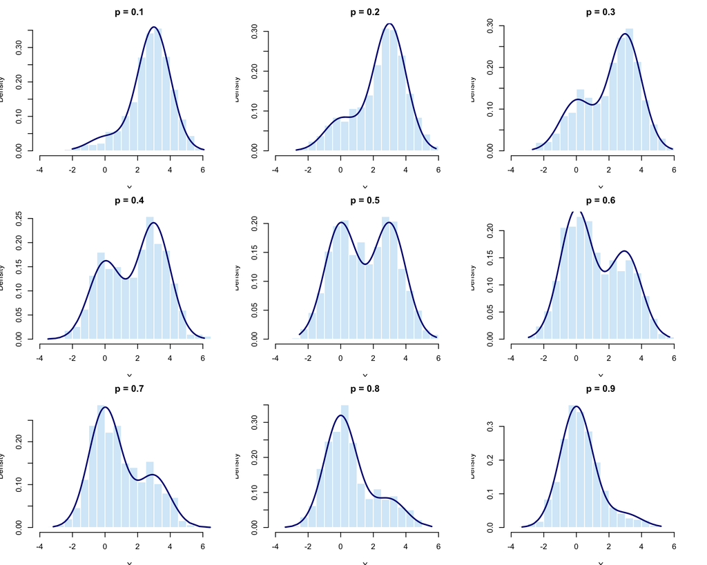

```r
set.seed(361)
n   <- 1000
p_vals <- seq(0.1, 0.9, length.out = 9)

par(mfrow = c(3, 3), mar = c(3.5, 3.5, 2.5, 1))

for (p_i in p_vals) {
  mu_i <- sample(c(0, 3), size = n, replace = TRUE, prob = c(p_i, 1 - p_i))
  x    <- rnorm(n, mean = mu_i, sd = 1)

  hist(x, breaks = "Scott", prob = TRUE,
       main  = paste0("p = ", round(p_i, 2)),
       xlab  = "X", col = "#D6EAF8", border = "white",
       xlim  = c(-4, 7))
  y_s  <- sort(x)
  fy_s <- p_i * dnorm(y_s, 0, 1) + (1 - p_i) * dnorm(y_s, 3, 1)
  lines(y_s, fy_s, col = "navy", lwd = 2)
}
```

```r
par(mfrow = c(1,1))
```

**Key observations from the $p_1$ grid:**

| $p_1$ range | Appearance | Why |
| --- | --- | --- |
| $p_1 \approx 0.1$ | Near unimodal, peak at 3 | Almost entirely from $N(3,1)$ |
| $p_1 \approx 0.3$–$0.4$ | **Clearly bimodal** | Both components visible |
| $p_1 = 0.5$ | **Most symmetric bimodal** | Equal weight to both components |
| $p_1 \approx 0.6$–$0.7$ | **Bimodal, left peak dominant** | $N(0,1)$ contributes more |
| $p_1 \approx 0.9$ | Near unimodal, peak at 0 | Almost entirely from $N(0,1)$ |

**Conclusion:** With means separated by $3\sigma$, bimodality is most visible at intermediate $p_1$ values ($\approx 0.3$–$0.7$). When either component dominates ($p_1$ near 0 or 1), the mixture looks essentially unimodal.

# Exercise 1 — Exponential-Gamma Continuous Mixture

Simulate a **continuous Exponential-Gamma mixture** with $\Lambda \sim \text{Gamma}(r=4,\, \beta=2)$ and $Y|\Lambda=\lambda \sim \text{Exp}(\lambda)$. Generate $n=1000$ observations and plot the histogram.

## Theory

**Hierarchical (continuous mixture) model:**
$$\Lambda \sim \text{Gamma}(r, \beta), \quad
Y|\Lambda=\lambda \sim \text{Exp}(\lambda)$$

**Marginal distribution of $Y$:**

By integrating out $\Lambda$:
$$f_Y(y) = \int_0^\infty \lambda e^{-\lambda
y} \cdot \frac{\beta^r}{\Gamma(r)} \lambda^{r-1} e^{-\beta\lambda}\,
d\lambda = \frac{r\beta^r}{(\beta + y)^{r+1}}$$

This is a **Pareto distribution**: $Y \sim \text{Pareto}(r,\, \beta)$ (Lomax form).

**Moments:** $E(Y) = \beta/(r-1) = 2/3 \approx 0.667$ (for $r > 1$), $\text{Var}(Y) = r\beta^2/[(r-1)^2(r-2)] = 4\cdot4/(9\cdot2) \approx 0.889$ (for $r > 2$)

**Simulation algorithm:** 1. Generate $\lambda_i \sim \text{Gamma}(r, \beta)$ — a rate for each observation 2. Generate $Y_i \sim \text{Exp}(\lambda_i)$ — using the sampled rate

## Solution

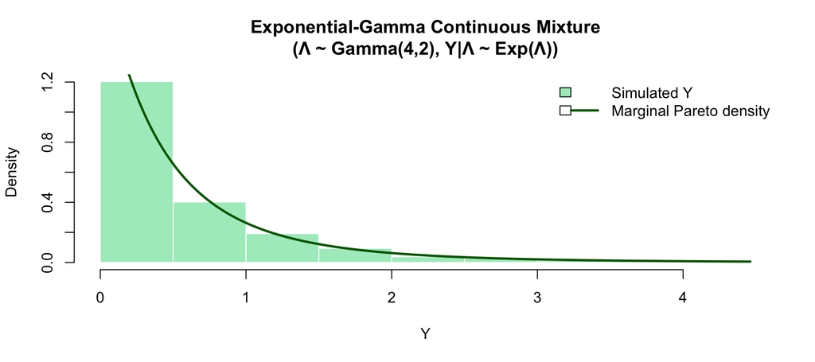

```r
set.seed(361)

n    <- 1000
r    <- 4
beta <- 2

# ---------------------------------------------------------------
# Step 1: Sample lambda ~ Gamma(r, beta) for each observation
#         These are individual rate parameters
# ---------------------------------------------------------------
lambda_i <- rgamma(n, shape = r, rate = beta)

# Step 2: Generate Y_i ~ Exp(lambda_i) for each sampled lambda
y_mix <- rexp(n, rate = lambda_i)

# Plot
hist(y_mix, prob = TRUE, breaks = "Scott",
     main = "Exponential-Gamma Continuous Mixture\n(Λ ~ Gamma(4,2), Y|Λ ~ Exp(Λ))",
     xlab = "Y", col = "#ABEBC6", border = "white",
     xlim = c(0, quantile(y_mix, 0.99)))

# Overlay the marginal Pareto density: f(y) = r*beta^r / (beta+y)^(r+1)
y_seq <- seq(0.001, quantile(y_mix, 0.99), 0.01)
f_pareto <- r * beta^r / (beta + y_seq)^(r+1)
lines(y_seq, f_pareto, col = "darkgreen", lwd = 2.5)

legend("topright",
       legend = c("Simulated Y", "Marginal Pareto density"),
       fill   = c("#ABEBC6", NA), lty = c(NA,1), lwd = c(NA,2.5),
       col    = c("black","darkgreen"), bty = "n")
```

```r
# Summary statistics
E_Y   <- beta / (r - 1)
Var_Y <- r * beta^2 / ((r-1)^2 * (r-2))

results_ex1 <- data.frame(
  Mean     = round(c(E_Y,   mean(y_mix)), 4),
  Variance = round(c(Var_Y, var(y_mix)),  4),
  row.names = c("Theoretical (Pareto marginal)", "Estimated")
)
kable(results_ex1, caption = "Exercise 1: Marginal Distribution Moments")
```

Exercise 1: Marginal Distribution Moments

|  | Mean | Variance |
| --- | --- | --- |
| Theoretical (Pareto marginal) | 0.6667 | 0.8889 |
| Estimated | 0.6505 | 0.8754 |

**Interpretation:** When $\Lambda$ is random (Gamma-distributed), the conditional Exponential model becomes a **Pareto marginal distribution** — a heavy-tailed distribution. This is a classic **variance-mean mixture**: variability in the rate $\Lambda$ induces extra dispersion in $Y$ compared to a simple $\text{Exp}(\bar{\lambda})$ model.

The theoretical Pareto density (green curve) fits the simulated histogram, confirming the mathematical derivation. The heavy right tail reflects that some observations with very small $\lambda$ produce very large $Y$ values.

# Exercise 2 — Chi-Square Convolution vs. Mixture

Write a function that generates $X_1 \sim \chi^2(2)$ and $X_2 \sim \chi^2(5)$ independently and compares the histograms of the **convolution** $S = X_1 + X_2$ and the **mixture** $F_X = 0.5 F_{X_1} + 0.5 F_{X_2}$.

## Theory

**Convolution:** Since $\chi^2_2$ and $\chi^2_5$ are both special cases of Gamma ($\chi^2_k = \text{Gamma}(k/2,\, 1/2)$):
$$X_1 + X_2 \sim \chi^2_{2+5}
= \chi^2_7$$

$E(S) = 2+5 = 7$, $\text{Var}(S) = 2(2+5) = 14$

**Mixture:** $F_X = 0.5\, F_{\chi^2_2} + 0.5\, F_{\chi^2_5}$

$E(X) = 0.5 \times 2 + 0.5 \times 5 = 3.5$, which is less than $E(S) = 7$.

We generate each $\chi^2$ as a sum of squared $N(0,1)$ variates.

## Solution

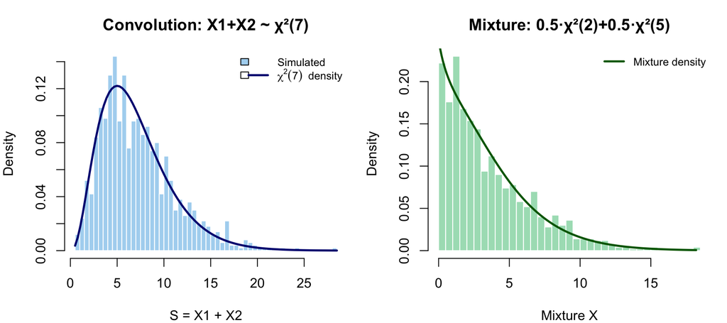

```
##
## --- Convolution S ~ chi-square( 7 ) ---
## Theoretical: E = 7 , Var = 14
## Estimated:   E = 7.2576 , Var = 15.9382
##
## --- Mixture ---
## Theoretical: E = 3.5
## Estimated:   E = 3.5818
```

```r
set.seed(361)

# ---------------------------------------------------------------
# chisquare_comp: generates n samples from chi-sq(k) and chi-sq(t)
#   via sum of squared normals, then compares convolution and mixture
# ---------------------------------------------------------------
chisquare_comp <- function(n, k, t) {

  # X1 ~ chi-square(k): sum of k squared N(0,1) per row
  z1 <- matrix(rnorm(n * k), nrow = n, ncol = k)
  x1 <- rowSums(z1^2)

  # X2 ~ chi-square(t): sum of t squared N(0,1) per row
  z2 <- matrix(rnorm(n * t), nrow = n, ncol = t)
  x2 <- rowSums(z2^2)

  # Convolution: S = X1 + X2 ~ chi-square(k+t)
  s <- x1 + x2

  # Mixture: randomly select X1 or X2 with equal probability
  u <- runif(n)
  m_ind <- as.integer(u > 0.5)
  x_mix <- m_ind * x1 + (1 - m_ind) * x2

  # Plot
  par(mfcol = c(1, 2), mar = c(4, 4, 3, 1))

  hist(s, prob = TRUE, col = "#AED6F1", border = "white", breaks = 40,
       main = paste0("Convolution: X1+X2 ~ \u03c7\u00b2(", k+t, ")"),
       xlab = "S = X1 + X2")
  curve(dchisq(x, df = k + t), col = "navy", lwd = 2.5, add = TRUE)
  legend("topright",
         legend = c("Simulated", bquote(chi^2*(.(k+t))~" density")),
         fill = c("#AED6F1",NA), lty=c(NA,1), lwd=c(NA,2.5),
         col=c("black","navy"), bty="n", cex=0.8)

  hist(x_mix, prob = TRUE, col = "#A9DFBF", border = "white", breaks = 40,
       main = paste0("Mixture: 0.5\u00b7\u03c7\u00b2(", k,")+0.5\u00b7\u03c7\u00b2(",t,")"),
       xlab = "Mixture X")
  x_seq  <- seq(0, max(x_mix), 0.1)
  f_mix  <- 0.5 * dchisq(x_seq, df = k) + 0.5 * dchisq(x_seq, df = t)
  lines(x_seq, f_mix, col = "darkgreen", lwd = 2.5)
  legend("topright", "Mixture density",
         lty=1, lwd=2.5, col="darkgreen", bty="n", cex=0.8)

  par(mfcol = c(1,1))

  # Summary table
  cat("\n--- Convolution S ~ chi-square(", k+t, ") ---\n")
  cat("Theoretical: E =", k+t, ", Var =", 2*(k+t), "\n")
  cat("Estimated:   E =", round(mean(s),4), ", Var =", round(var(s),4), "\n")

  cat("\n--- Mixture ---\n")
  cat("Theoretical: E =", 0.5*k + 0.5*t, "\n")
  cat("Estimated:   E =", round(mean(x_mix),4), "\n")
}

# Run with the specified parameters
n <- 1000   # sample size
k <- 2      # degrees of freedom for X1
t <- 5      # degrees of freedom for X2
chisquare_comp(n, k, t)
```